# pulmonic_stenosis_data_simulation

Alex German

2026-08-10

# Check working directory

```r
getwd()
```

```
## [1] "/Users/alexg/Documents/R files/pulmonic_stenosis"
```

# Load packages

```r
library(readxl)
library(psych)
library(dlookr)
library(vtable)
library(dplyr)
library(tidyr)
library(purrr)
library(reshape)
library(vioplot)

library(tidyverse)
library(pammtools)
library(splines2)
library(posterior)
library(ggplot2)
library(rethinking)
library(survminer)
library(survival)
library(cowplot)
library(rstanarm)
library(bayestestR)
library(brms)
library(tidybayes)
library(bayesplot)
library(simsurv)
library(sn)
```

# 1. Create synthetic dataset 1 for testing

Simple associations but no interactions ## a. Define covariates

```r
# Define number of individuals
n_subjects <- 200

# Simulate covariates: e.g., a binary treatment variable (trt) and age
set.seed(123)
covariates <- data.frame(
  id = 1:n_subjects,
  surgery = rbinom(n_subjects, 1, 0.6), # 60% chance of surgery
  chf = rbinom(n_subjects, 1, 0.2), # 20% chance of chf
  s_age = rsn(n = n_subjects, xi = 0, omega = 1, alpha = 4)   # Standardised age in months as skew-normal distribution
)
```

## b. Generate true survival times

```r
# Define the true parameter values (log hazard ratios for covariates)
# The 'names' correspond to column names in the 'covariates' data frame
betas <- c(surgery = -0.5, s_age = 0.03, chf = 2.0)

# Define the shape (gamma) and scale (lambda) parameters for the baseline Weibull distribution
# Note: 'simsurv' uses 'gammas' for shape and 'lambdas' for scale
# Setting gamma=1 results in an exponential distribution
gammas <- c(shape = 0.75)
lambdas <- c(scale = 0.01)


# Simulate event times
set.seed(123)
true_event_times <- simsurv(
  dist = "weibull",
  x = covariates,
  betas = betas,
  gammas = gammas,
  lambdas = lambdas
)

# Combine with covariates for a complete dataset
sim_data <- merge(covariates, true_event_times, by = "id")
sim_data <- sim_data |>
  mutate(centre = sample(x = LETTERS[1:3], size = n_subjects, replace=TRUE))
```

## c. Incorporate censoring

```r
# Define a maximum follow-up time (e.g., 5 years)
max_follow_up <- 3000

# Simulate a random censoring time (e.g., uniform distribution up to max_follow_up)
# The actual censoring time could also be dependent on other factors
set.seed(123)
sim_data$censor_time <- runif(n_subjects, 0, max_follow_up)

# Determine observed time and event status
sim_data$time <- pmin(sim_data$eventtime, sim_data$censor_time)
sim_data$status <- as.numeric(sim_data$eventtime <= sim_data$censor_time) # 1 = event, 0 = censored
```

## d. Generate data summary of synthetic data 1

```r
sumtable(sim_data)
```

Summary Statistics

| Variable | N | Mean | Std. Dev. | Min | Pctl. 25 | Pctl. 75 | Max |
| --- | --- | --- | --- | --- | --- | --- | --- |
| id | 200 | 100 | 58 | 1 | 51 | 150 | 200 |
| surgery | 200 | 0.61 | 0.49 | 0 | 0 | 1 | 1 |
| chf | 200 | 0.19 | 0.39 | 0 | 0 | 0 | 1 |
| s_age | 200 | 0.77 | 0.64 | -0.42 | 0.31 | 1.2 | 3 |
| eventtime | 200 | 640 | 1026 | 0.0019 | 59 | 751 | 7780 |
| status | 200 | 0.8 | 0.4 | 0 | 1 | 1 | 1 |
| centre | 200 |  |  |  |  |  |  |
| … A | 66 | 33% |  |  |  |  |  |
| … B | 70 | 35% |  |  |  |  |  |
| … C | 64 | 32% |  |  |  |  |  |
| censor_time | 200 | 1519 | 822 | 1.9 | 816 | 2200 | 2983 |
| time | 200 | 409 | 460 | 0.0019 | 56 | 655 | 2862 |

# 2. Create synthetic dataset 2 for testing

Simple associations with interaction of chf on clinical_signs ## a. Define covariates

```r
# Set seed for reproducibility
set.seed(123)

# Define number of individuals
n_subjects <- 250

prob_impact <- 0.75 # Probability of 'impacted' being 1 when 'influencer' is 1
prob_no_impact <- 0.25 # Base probability of 'impacted' being 1 when 'influencer' is 0


# Create the Influencing Variable (chf)
# Simulate a binary variable (0 or 1)
chf = rbinom(n_subjects, 1, 0.5) # 50% chance of chf


# Create the Impacted Variable (clinical_signs) ---
# Use case_when to create Y based on X, with controlled probabilities
clinical_signs <- case_when(
  chf == 1 ~ rbinom(n_subjects, 1, prob_impact), # If influencer is 1, Y has high chance (75%) of being 1
  chf == 0 ~ rbinom(n_subjects, 1, prob_no_impact) # If influencer is 0, Y has low chance (25%) of being 1
)


# Simulate covariates: e.g., a binary treatment variable (trt) and age

covariates2 <- data.frame(
  id = 1:n_subjects,
  chf = chf,
  clinical_signs = clinical_signs
)
```

## b. Generate true survival times

```r
# Define the true parameter values (log hazard ratios for covariates)
# The 'names' correspond to column names in the 'covariates' data frame
betas2 <- c(clinical_signs = 0, chf = 0.75)

# Define the shape (gamma) and scale (lambda) parameters for the baseline Weibull distribution
# Note: 'simsurv' uses 'gammas' for shape and 'lambdas' for scale
# Setting gamma=1 results in an exponential distribution
gammas <- c(shape = 0.4)
lambdas <- c(scale = 0.01)


# Simulate event times
set.seed(123)
true_event_times2 <- simsurv(
  dist = "weibull",
  x = covariates2,
  betas = betas2,
  gammas = gammas,
  lambdas = lambdas
)

# Combine with covariates2 for a complete dataset
sim_data2 <- merge(covariates2, true_event_times2, by = "id")
sim_data2 <- sim_data2 |>
  mutate(centre = sample(x = LETTERS[1:3], size = n_subjects, replace=TRUE))
```

## c. Incorporate censoring

```r
# Define a maximum follow-up time (e.g., 5 years)
max_follow_up <- 3000

# Simulate a random censoring time (e.g., uniform distribution up to max_follow_up)
# The actual censoring time could also be dependent on other factors
set.seed(123)
sim_data2$censor_time <- runif(n_subjects, 0, max_follow_up)

# Determine observed time and event status
sim_data2$time <- pmin(sim_data2$eventtime, sim_data2$censor_time)
sim_data2$status <- as.numeric(sim_data2$eventtime <= sim_data2$censor_time) # 1 = event, 0 = censored
```

## d. Generate data summary of synthetic data 2

```r
sumtable(sim_data2)
```

Summary Statistics

| Variable | N | Mean | Std. Dev. | Min | Pctl. 25 | Pctl. 75 | Max |
| --- | --- | --- | --- | --- | --- | --- | --- |
| id | 250 | 126 | 72 | 1 | 63 | 188 | 250 |
| chf | 250 | 0.49 | 0.5 | 0 | 0 | 1 | 1 |
| clinical_signs | 250 | 0.51 | 0.5 | 0 | 0 | 1 | 1 |
| eventtime | 250 | 203728 | 733041 | 0.0000022 | 2672 | 108267 | 9570169 |
| status | 250 | 0.21 | 0.41 | 0 | 0 | 0 | 1 |
| centre | 250 |  |  |  |  |  |  |
| … A | 91 | 36% |  |  |  |  |  |
| … B | 81 | 32% |  |  |  |  |  |
| … C | 78 | 31% |  |  |  |  |  |
| censor_time | 250 | 1523 | 820 | 1.9 | 823 | 2178 | 2983 |
| time | 250 | 1227 | 852 | 0.0000022 | 477 | 1897 | 2957 |

# 3. Create synthetic dataset 3 for testing

Again, interaction between chf and clinical_signs, with an additional effect of clinical_signs ## a. Define covariates

```r
# Set seed for reproducibility
set.seed(123)

# Define number of individuals
n_subjects <- 250

prob_impact <- 0.75 # Probability of 'impacted' being 1 when 'influencer' is 1
prob_no_impact <- 0.25 # Base probability of 'impacted' being 1 when 'influencer' is 0


# Create the Influencing Variable (chf)
# Simulate a binary variable (0 or 1)
chf = rbinom(n_subjects, 1, 0.5) # 50% chance of chf


# Create the Impacted Variable (clinical_signs) ---
# Use case_when to create Y based on X, with controlled probabilities
clinical_signs <- case_when(
  chf == 1 ~ rbinom(n_subjects, 1, prob_impact), # If influencer is 1, Y has high chance (75%) of being 1
  chf == 0 ~ rbinom(n_subjects, 1, prob_no_impact) # If influencer is 0, Y has low chance (25%) of being 1
)


# Simulate covariates: e.g., a binary treatment variable (trt) and age

covariates3 <- data.frame(
  id = 1:n_subjects,
  chf = chf,
  clinical_signs = clinical_signs
)
```

## b. Generate true survival times

```r
# Define the true parameter values (log hazard ratios for covariates)
# The 'names' correspond to column names in the 'covariates' data frame
betas3 <- c(clinical_signs = 0.5, chf = 0.5)

# Define the shape (gamma) and scale (lambda) parameters for the baseline Weibull distribution
# Note: 'simsurv' uses 'gammas' for shape and 'lambdas' for scale
# Setting gamma=1 results in an exponential distribution
gammas <- c(shape = 0.4)
lambdas <- c(scale = 0.01)


# Simulate event times
set.seed(123)
true_event_times2 <- simsurv(
  dist = "weibull",
  x = covariates3,
  betas = betas3,
  gammas = gammas,
  lambdas = lambdas
)

# Combine with covariates2 for a complete dataset
sim_data3 <- merge(covariates3, true_event_times2, by = "id")
sim_data3 <- sim_data3 |>
  mutate(centre = sample(x = LETTERS[1:3], size = n_subjects, replace=TRUE))
```

## c. Incorporate censoring

```r
# Define a maximum follow-up time (e.g., 5 years)
max_follow_up <- 3000

# Simulate a random censoring time (e.g., uniform distribution up to max_follow_up)
# The actual censoring time could also be dependent on other factors
set.seed(123)
sim_data3$censor_time <- runif(n_subjects, 0, max_follow_up)

# Determine observed time and event status
sim_data3$time <- pmin(sim_data3$eventtime, sim_data3$censor_time)
sim_data3$status <- as.numeric(sim_data3$eventtime <= sim_data3$censor_time) # 1 = event, 0 = censored
```

## d. Generate data summary of synthetic data 3

```r
sumtable(sim_data3)
```

Summary Statistics

| Variable | N | Mean | Std. Dev. | Min | Pctl. 25 | Pctl. 75 | Max |
| --- | --- | --- | --- | --- | --- | --- | --- |
| id | 250 | 126 | 72 | 1 | 63 | 188 | 250 |
| chf | 250 | 0.49 | 0.5 | 0 | 0 | 1 | 1 |
| clinical_signs | 250 | 0.51 | 0.5 | 0 | 0 | 1 | 1 |
| eventtime | 250 | 172540 | 706487 | 0.0000022 | 2012 | 76054 | 9570169 |
| status | 250 | 0.24 | 0.43 | 0 | 0 | 0 | 1 |
| centre | 250 |  |  |  |  |  |  |
| … A | 91 | 36% |  |  |  |  |  |
| … B | 81 | 32% |  |  |  |  |  |
| … C | 78 | 31% |  |  |  |  |  |
| censor_time | 250 | 1523 | 820 | 1.9 | 823 | 2178 | 2983 |
| time | 250 | 1180 | 842 | 0.0000022 | 445 | 1847 | 2957 |

# 3. Check effects in dataset 1

# I. Bayesian Cox’s regression for EFFECT OF SURGERY (surgery y/n) with random intercept for centre

### i. surgery

**Set a non_informative weakly regularising prior…**

student_t(df = 3, location = 0, scale = 2)

```r
prior_surgery <- student_t(df = 3,
                           location = 0,
                           scale = 2,
                           autoscale = FALSE)
```

## Fit model with for surgery

NB use status … rstanarm requires the dead animals to be classified as 1, whilst censored are 0.

```r
mod_sx <- stan_surv(formula = Surv(time, status) ~ 1 + surgery +  (1| centre),
  data = sim_data,
  basehaz = "ms",
  prior = prior_surgery,
  prior_intercept = normal(location = 0, scale = 20, autoscale = FALSE),
  prior_covariance =  decov(regularization = 2, concentration = 1, shape = 1, scale = 1),
  iter    = 2000,
  chains = 4,
  cores = 4,
  adapt_delta = 0.999,  # Often helpful for complex models
  seed = 666)
```

[output not shown]

```
## Also defined by 'rstan'
```

[output not shown]

```
## Also defined by 'rstan'
```

[output not shown]

```
## Also defined by 'rstan'
```

[output not shown]

```
## Also defined by 'rstan'
```

[output not shown]

```
## Also defined by 'rstan'
```

## Summarise priors from model

```r
prior_summary(mod_sx)
```

```
## Priors for model 'mod_sx'
## ------
## Intercept
##  ~ normal(location = 0, scale = 20)
##
## Coefficients
##  ~ student_t(df = 3, location = 0, scale = 2)
##
## Auxiliary (M-spline-coefficients)
##  ~ dirichlet(concentration = [1,1,1,...])
##
## Covariance
##  ~ decov(reg. = 2, conc. = 1, shape = 1, scale = 1)
## ------
## See help('prior_summary.stanreg') for more details
```

## Model summary

```r
summary(mod_sx)
```

```
##
## Model Info:
##
##  function:        stan_surv
##  baseline hazard: M-splines on hazard scale
##  formula:         Surv(time, status) ~ 1 + surgery + (1 | centre)
##  algorithm:       sampling
##  sample:          4000 (posterior sample size)
##  priors:          see help('prior_summary')
##  observations:    200
##  events:          159 (79.5%)
##  right censored:  41 (20.5%)
##  delayed entry:   no
##
## Estimates:
##                                         mean   sd   10%   50%   90%
## (Intercept)                            1.4    0.2  1.1   1.4   1.7
## surgery                               -0.5    0.2 -0.7  -0.5  -0.3
## m-splines-coef1                        0.0    0.0  0.0   0.0   0.1
## m-splines-coef2                        0.1    0.0  0.1   0.1   0.1
## m-splines-coef3                        0.4    0.1  0.2   0.4   0.5
## m-splines-coef4                        0.3    0.1  0.1   0.3   0.5
## m-splines-coef5                        0.1    0.1  0.0   0.1   0.3
## m-splines-coef6                        0.1    0.1  0.0   0.1   0.2
## b[(Intercept) centre:A]                0.0    0.2 -0.2   0.0   0.1
## b[(Intercept) centre:B]                0.0    0.2 -0.1   0.0   0.2
## b[(Intercept) centre:C]                0.0    0.2 -0.1   0.0   0.2
## Sigma[centre:(Intercept),(Intercept)]  0.1    0.3  0.0   0.0   0.2
##
## MCMC diagnostics
##                                       mcse Rhat n_eff
## (Intercept)                           0.0  1.0  1674
## surgery                               0.0  1.0  3874
## m-splines-coef1                       0.0  1.0  4007
## m-splines-coef2                       0.0  1.0  4660
## m-splines-coef3                       0.0  1.0  2438
## m-splines-coef4                       0.0  1.0  1973
## m-splines-coef5                       0.0  1.0  3100
## m-splines-coef6                       0.0  1.0  4212
## b[(Intercept) centre:A]               0.0  1.0  1570
## b[(Intercept) centre:B]               0.0  1.0  1535
## b[(Intercept) centre:C]               0.0  1.0  1507
## Sigma[centre:(Intercept),(Intercept)] 0.0  1.0  1824
## log-posterior                         0.1  1.0  1304
##
## For each parameter, mcse is Monte Carlo standard error, n_eff is a crude measure of effective sample size, and Rhat is the potential scale reduction factor on split chains (at convergence Rhat=1).
```

## Model short summary

```r
print(mod_sx, digits = 3)
```

```
## stan_surv
##  baseline hazard: M-splines on hazard scale
##  formula:         Surv(time, status) ~ 1 + surgery + (1 | centre)
##  observations:    200
##  events:          159 (79.5%)
##  right censored:  41 (20.5%)
##  delayed entry:   no
## ------
##                 Median MAD_SD exp(Median)
## (Intercept)      1.389  0.209     NA
## surgery         -0.460  0.163  0.631
## m-splines-coef1  0.039  0.011     NA
## m-splines-coef2  0.098  0.024     NA
## m-splines-coef3  0.351  0.099     NA
## m-splines-coef4  0.288  0.141     NA
## m-splines-coef5  0.095  0.092     NA
## m-splines-coef6  0.073  0.072     NA
##
## Error terms:
##  Groups Name        Std.Dev.
##  centre (Intercept) 0.3095
## Num. levels: centre 3
##
## ------
## * For help interpreting the printed output see ?print.stanreg
## * For info on the priors used see ?prior_summary.stanreg
```

## Plot Baseline hazard of model

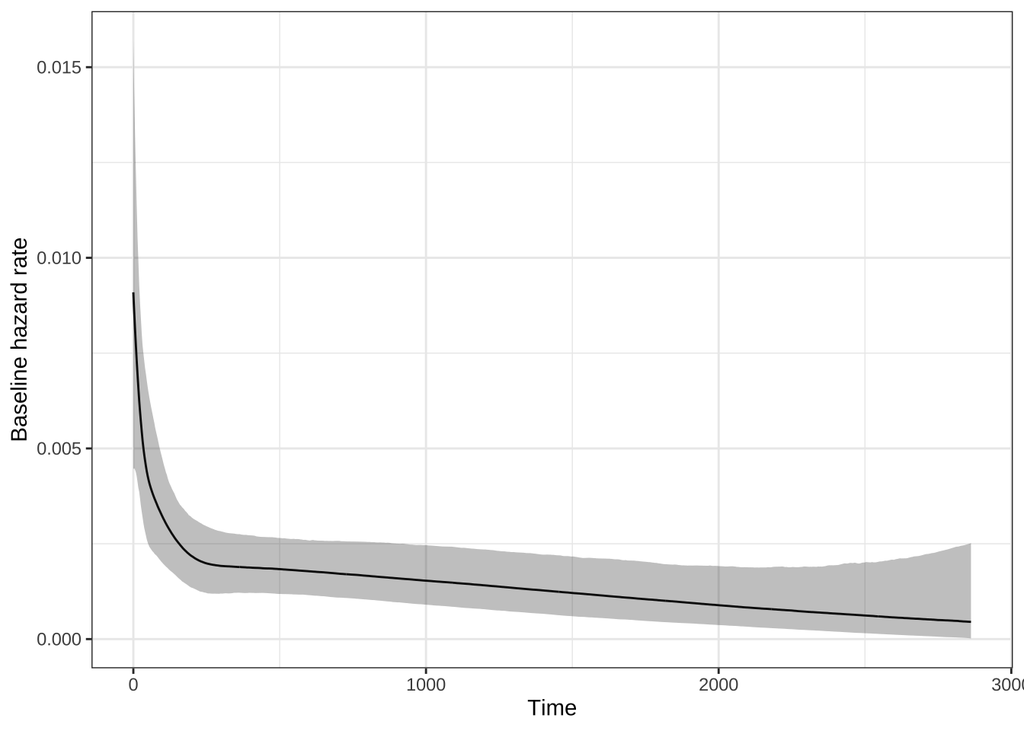

```r
plot(mod_sx)
```

## Plots of model convergences

## Get results

```r
posterior_mod_sx <- as.array(mod_sx)
```

### a. Check trace plots for model

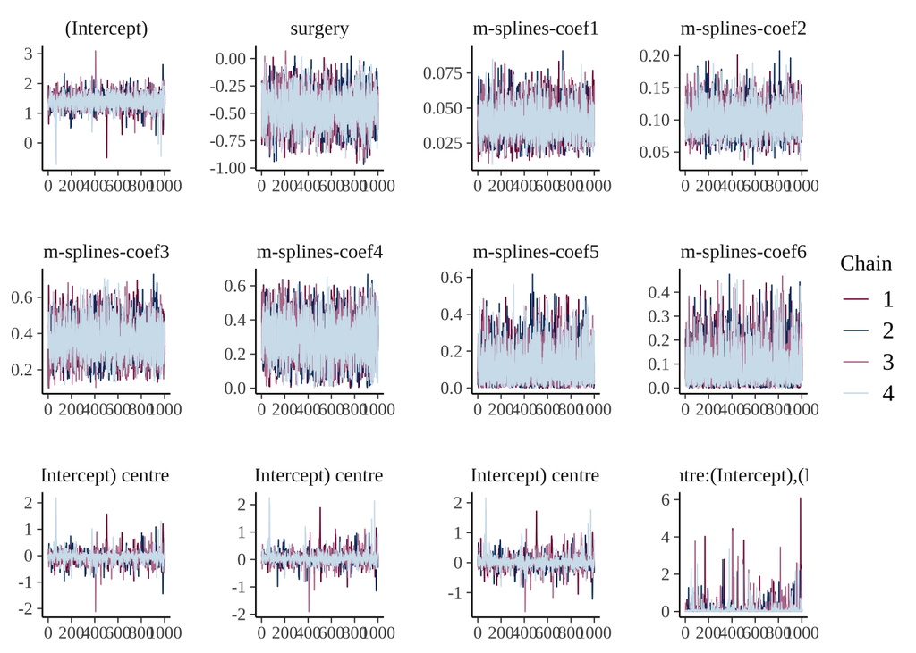

```r
color_scheme_set("mix-blue-pink")
mcmc_trace(posterior_mod_sx)
```

### b. Trace rank plot

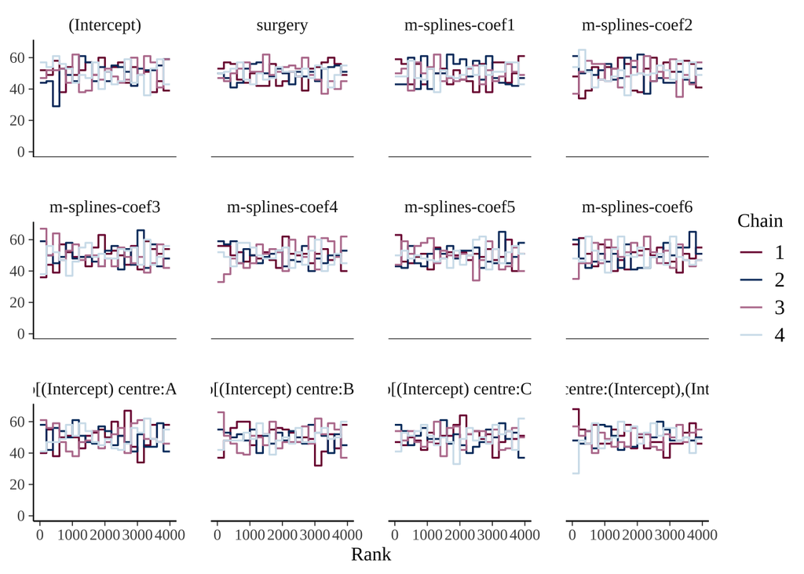

```r
mcmc_rank_overlay(posterior_mod_sx)
```

### c. get dens overlay plot for chains

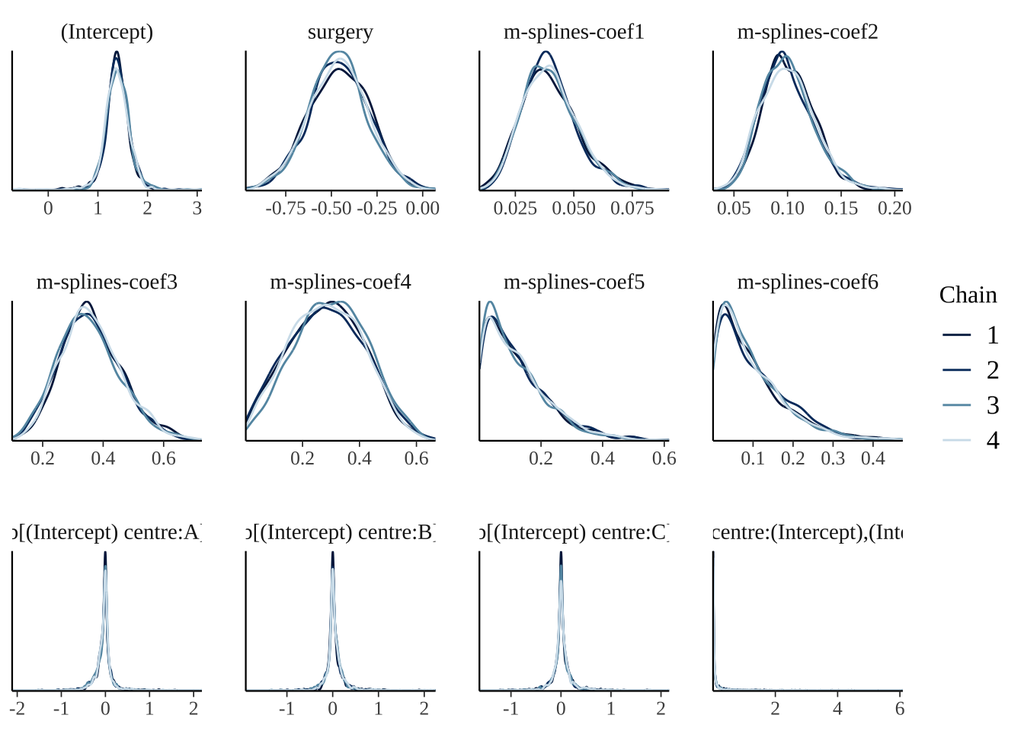

```r
color_scheme_set("blue")
mcmc_dens_overlay(posterior_mod_sx)
```

## Summaries of coefficients

### HPDI for the different beta parameters

```r
draws <- as.matrix(mod_sx)
median(draws[,2]) # 2nd column is draws for surgery
```

```
## [1] -0.4598279
```

```r
HPDI(draws[,2], 0.97) # 2nd column is draws for surgery
```

```
##      |0.97      0.97|
## -0.8290091 -0.1217680
```

```r
HPDI(draws[,2], 0.89) # 2nd column is draws for surgery
```

```
##      |0.89      0.89|
## -0.7270618 -0.2090704
```

### Hypothesis tests on beta parameters

#### surgery

probability that effect is negative

```r
mean(draws[,2] < 0) # 2nd column is draws for surgery
```

```
## [1] 0.998
```

### a. Get HDI for coefficients

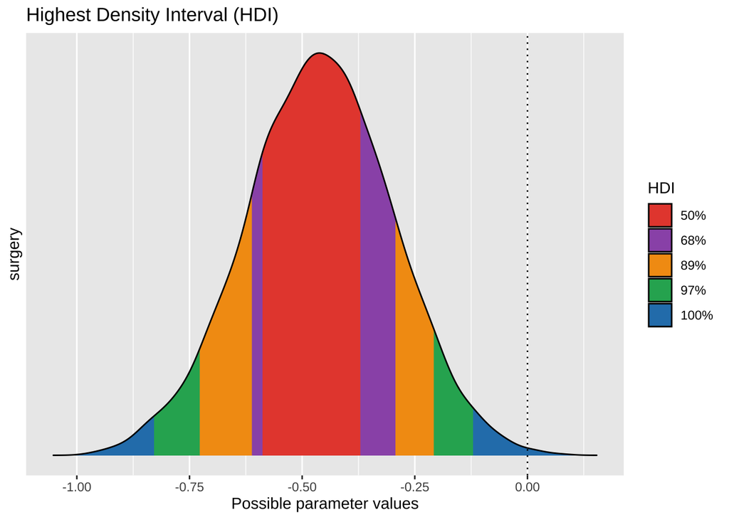

```r
hdi <- bayestestR::hdi(mod_sx, ci = c(0.50, 0.68, 0.89, 0.97), parameters = "surgery")
plot(hdi)
```

## Get density plots for posterior distributons of beta parameters

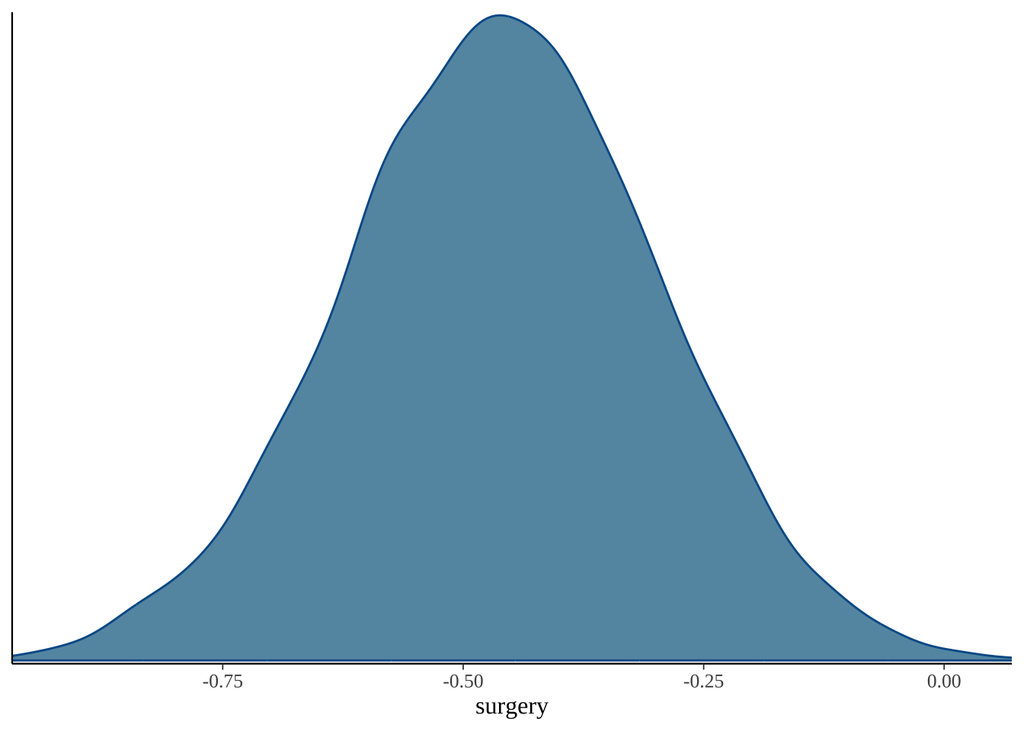

```r
mcmc_dens(posterior_mod_sx,
  pars = c("surgery"))
```

## Get area plot for posterior distributons of beta parameters

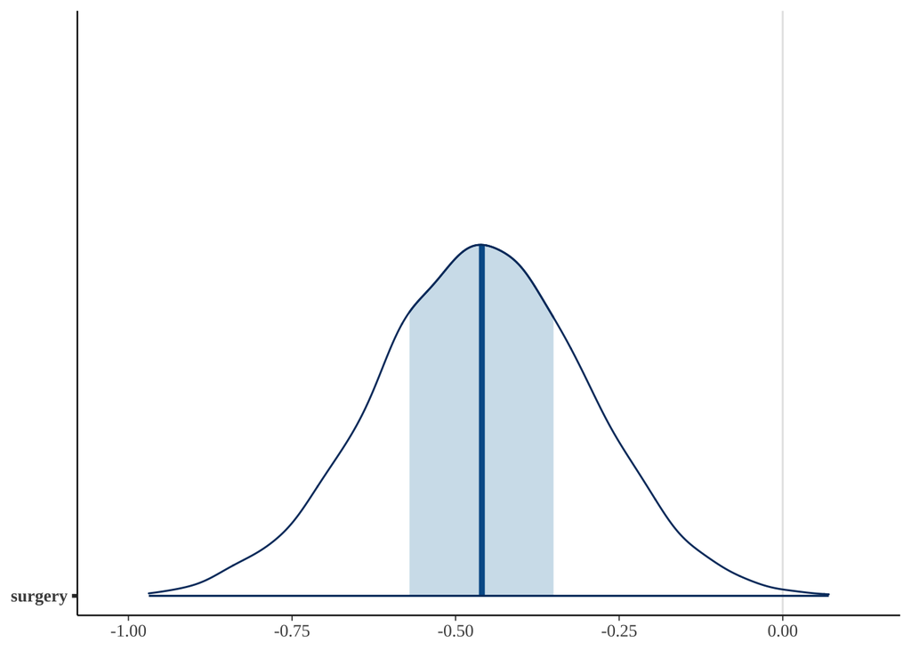

```r
mcmc_areas(posterior_mod_sx,
  pars = "surgery")
```

## Calculate hazard ratios for surgery

### a. get posterior draws

```r
surgery_hr <- exp(draws[,2]) # 2nd column is draws for surgery)
```

### b. Summarise hazard ratios for surgery

```r
median(surgery_hr)
```

```
## [1] 0.6313923
```

```r
hdi_surgery_hr <- hdi(surgery_hr, ci = c(0.50, 0.68, 0.89, 0.97))
hdi_surgery_hr
```

```
##           [,1]      [,2]
## [1,] 0.4364816 0.8376409
```

### c. Plot posterior distribution for hazard ratio of surgery

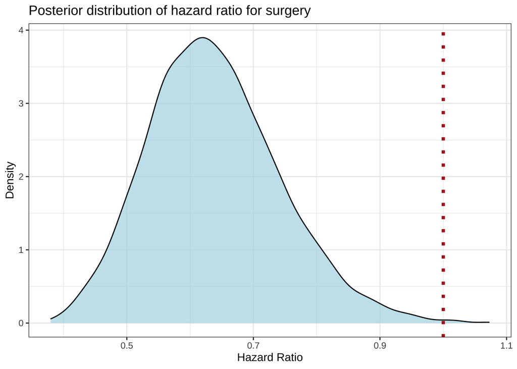

```r
ggplot(data.frame(surgery_hr), aes(x = surgery_hr)) +
  geom_density(fill = "lightblue", alpha = 0.7) +
  labs(title = "Posterior distribution of hazard ratio for surgery",
       x = "Hazard Ratio",
       y = "Density") +
  theme_bw() +
  geom_vline(xintercept = 1, linetype="dotted",
                color = "firebrick", linewidth = 1.5)
```

## Check model performance

### check performance of posterior probability

NB equivalent of pp_check

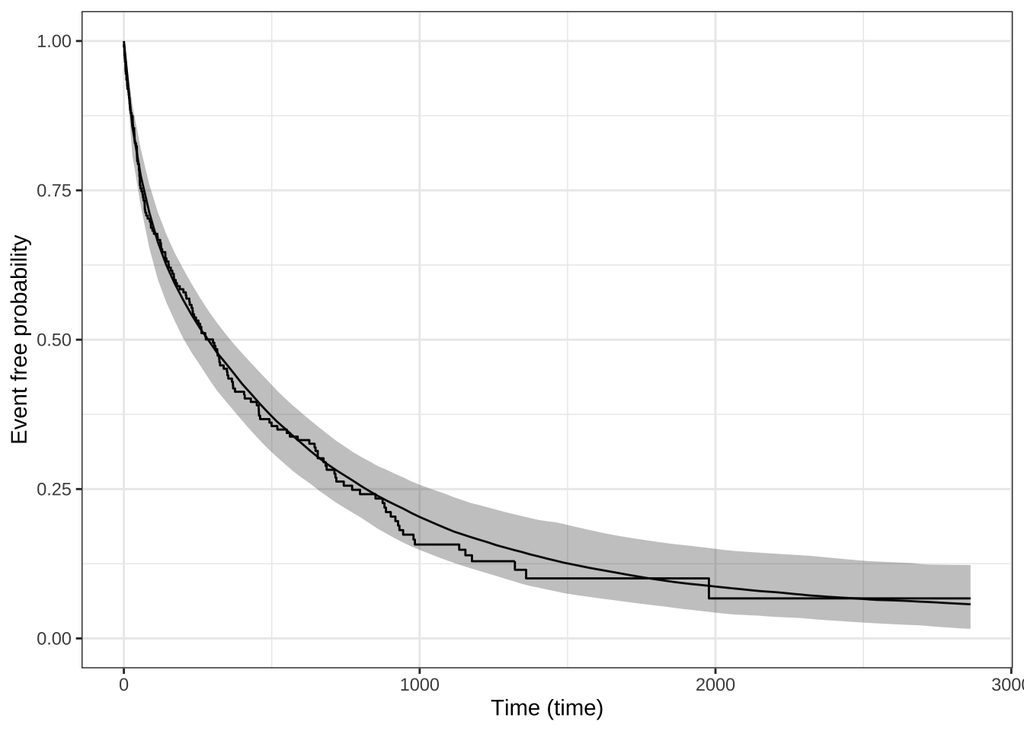

```r
ps_check(mod_sx) |>
  suppressWarnings()
```

### check performance of prior probability

```r
mod_final_prior_only <- update(mod_sx, prior_PD = TRUE)
```

[output not shown]

```
## Also defined by 'rstan'
```

[output not shown]

```
## Also defined by 'rstan'
```

[output not shown]

```
## Also defined by 'rstan'
```

[output not shown]

```
## Also defined by 'rstan'
```

[output not shown]

```
## Also defined by 'rstan'
```

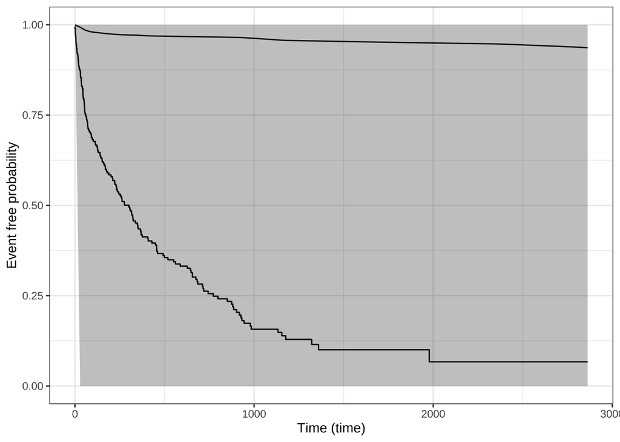

```r
ps_check(mod_final_prior_only) |>
  suppressWarnings()
```

## Make model predictions and plot for surgery

```r
nd <- data.frame(centre = rep("A", 2),
                 surgery = c(0, 1)
                 )
head(nd)
```

```
##   centre surgery
## 1      A       0
## 2      A       1
```

### make posterior predictions from new data

```r
ps <- posterior_survfit(mod_sx,
  newdata = nd,
  times = 0,
  extrapolate = TRUE) |>
  suppressWarnings()
head(ps)
```

```
## stan_surv predictions
##  num. individuals: 2
##  prediction type:  event free probability
##  standardised?:    no
##  conditional?:     no
##
##   id cond_time     time median  ci_lb  ci_ub
## 1  1        NA   0.0000 1.0000 1.0000 1.0000
## 2  1        NA  28.9119 0.8208 0.7521 0.8859
## 3  1        NA  57.8237 0.7221 0.6334 0.8037
## 4  1        NA  86.7356 0.6491 0.5532 0.7483
## 5  1        NA 115.6474 0.5927 0.4931 0.7035
## 6  1        NA 144.5593 0.5488 0.4492 0.6615
```

### plot

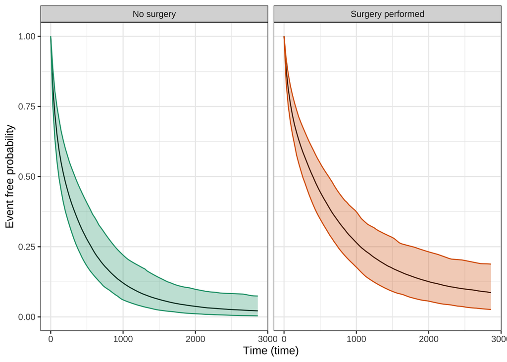

```r
panel_labels <- c('1' = "No surgery", '2' = "Surgery performed")
pps <- plot(ps) +
  aes(colour = factor(id), fill = factor(id)) +
  scale_colour_brewer(palette = "Dark2") +
  scale_fill_brewer(palette = "Dark2") +
  theme(legend.position = "none") +
  facet_wrap(~ id, labeller = labeller(id = panel_labels))
print(pps)
```

## Check PH assumption visually

### make predictions of both the hazard and log hazard

```r
ph <- suppressWarnings(posterior_survfit(mod_sx, newdata = nd, type = "haz"))
pl <- suppressWarnings(posterior_survfit(mod_sx, newdata = nd, type = "loghaz"))
```

#### create plots

```r
pph <- plot(ph) +
  facet_wrap(~ id, labeller = labeller(id = panel_labels))
ppl <- plot(pl) +
  facet_wrap(~ id, labeller = labeller(id = panel_labels))
```

#### combine plots in grid and plot

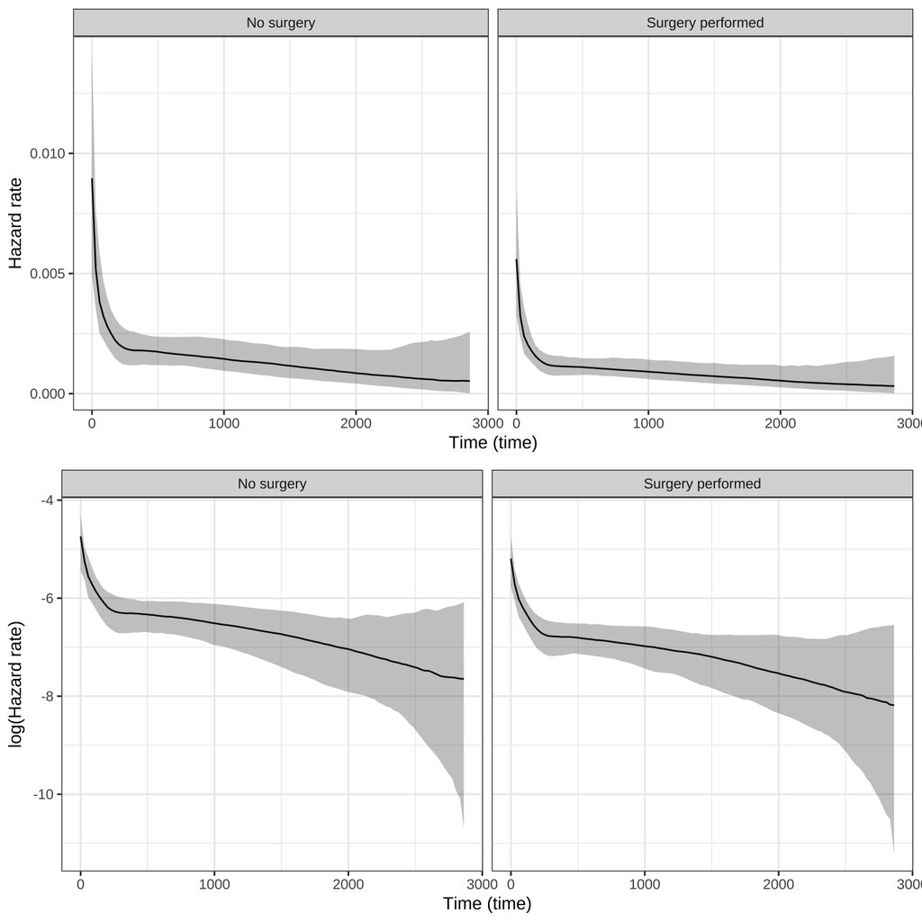

```r
plot_grid(pph, ppl, ncol = 1)
```

## Create KM curve

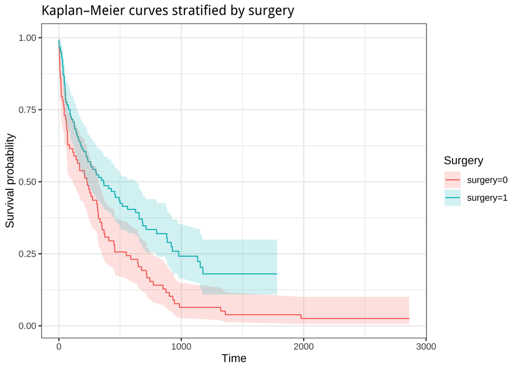

```r
# Basic KM curve for the entire dataset
km_strat <- survfit(Surv(time, status) ~ 1 + surgery, data = sim_data)

# Convert to tidy format
km_df <- broom::tidy(km_strat)


# Columns: time, estimate, conf.low, conf.high, strata, n.risk, n.event, n.censor
ggplot(km_df, aes(x = time, y = estimate, colour = strata, fill = strata)) +
  geom_step() +
  geom_ribbon(aes(ymin = conf.low, ymax = conf.high), alpha = 0.2, colour = NA) +
  theme_bw() +
  labs(
    x = "Time",
    y = "Survival probability",
    colour = "Surgery",
    fill = "Surgery",
    title = "Kaplan–Meier curves stratified by surgery"
  )
```

## Fit frequentist Cox PH model for effect of surgery

```r
# Fit Cox PH model
freq_cox_sx <- coxph(Surv(time, status) ~ 1 + surgery + strata(centre),
  data = sim_data)

summary(freq_cox_sx)
```

```
## Call:
## coxph(formula = Surv(time, status) ~ 1 + surgery + strata(centre),
##     data = sim_data)
##
##   n= 200, number of events= 159
##
##            coef exp(coef) se(coef)      z Pr(>|z|)
## surgery -0.4956    0.6092   0.1640 -3.022  0.00251 **
## ---
## Signif. codes:  0 '***' 0.001 '**' 0.01 '*' 0.05 '.' 0.1 ' ' 1
##
##         exp(coef) exp(-coef) lower .95 upper .95
## surgery    0.6092      1.642    0.4417    0.8401
##
## Concordance= 0.556  (se = 0.023 )
## Likelihood ratio test= 9  on 1 df,   p=0.003
## Wald test            = 9.13  on 1 df,   p=0.003
## Score (logrank) test = 9.3  on 1 df,   p=0.002
```

## II. Bayesian Cox’s regression for EFFECT of s_age with random intercept for centre

## Non-informative prior for s_age

**Set a non-informative weekly regularising prior…**

student_t(df = 3, location = 0, scale = 2)

```r
prior_s_age <- student_t(df = 3,
                           location = 0,
                           scale = 2,
                           autoscale = FALSE)
```

## Fit model

NB use status … rstanarm requires the dead animals to be classified as 1, whilst censored are 0.

```r
mod_s_age <- stan_surv(formula = Surv(time, status) ~ 1 + s_age +  (1| centre),
  data = sim_data,
  basehaz = "ms",
  prior = prior_s_age,
  prior_intercept = normal(location = 0, scale = 20, autoscale = FALSE),
  prior_covariance =  decov(regularization = 2, concentration = 1, shape = 1, scale = 1),
  iter    = 2000,
  chains = 4,
  cores = 4,
  adapt_delta = 0.999,  # Often helpful for complex models
  seed = 666)
```

[output not shown]

```
## Also defined by 'rstan'
```

[output not shown]

```
## Also defined by 'rstan'
```

[output not shown]

```
## Also defined by 'rstan'
```

[output not shown]

```
## Also defined by 'rstan'
```

[output not shown]

## Summarise priors from model

```r
prior_summary(mod_s_age)
```

```
## Priors for model 'mod_s_age'
## ------
## Intercept
##  ~ normal(location = 0, scale = 20)
##
## Coefficients
##  ~ student_t(df = 3, location = 0, scale = 2)
##
## Auxiliary (M-spline-coefficients)
##  ~ dirichlet(concentration = [1,1,1,...])
##
## Covariance
##  ~ decov(reg. = 2, conc. = 1, shape = 1, scale = 1)
## ------
## See help('prior_summary.stanreg') for more details
```

## Model summary

```r
summary(mod_s_age)
```

```
##
## Model Info:
##
##  function:        stan_surv
##  baseline hazard: M-splines on hazard scale
##  formula:         Surv(time, status) ~ 1 + s_age + (1 | centre)
##  algorithm:       sampling
##  sample:          4000 (posterior sample size)
##  priors:          see help('prior_summary')
##  observations:    200
##  events:          159 (79.5%)
##  right censored:  41 (20.5%)
##  delayed entry:   no
##
## Estimates:
##                                         mean   sd   10%   50%   90%
## (Intercept)                            1.2    0.3  0.9   1.2   1.5
## s_age                                 -0.1    0.1 -0.2   0.0   0.1
## m-splines-coef1                        0.0    0.0  0.0   0.0   0.1
## m-splines-coef2                        0.1    0.0  0.1   0.1   0.1
## m-splines-coef3                        0.3    0.1  0.2   0.3   0.5
## m-splines-coef4                        0.3    0.1  0.1   0.3   0.4
## m-splines-coef5                        0.1    0.1  0.0   0.1   0.3
## m-splines-coef6                        0.1    0.1  0.0   0.1   0.2
## b[(Intercept) centre:A]               -0.1    0.2 -0.3   0.0   0.1
## b[(Intercept) centre:B]                0.1    0.2 -0.1   0.0   0.3
## b[(Intercept) centre:C]                0.0    0.2 -0.2   0.0   0.2
## Sigma[centre:(Intercept),(Intercept)]  0.1    0.6  0.0   0.0   0.3
##
## MCMC diagnostics
##                                       mcse Rhat n_eff
## (Intercept)                           0.0  1.0   906
## s_age                                 0.0  1.0  4237
## m-splines-coef1                       0.0  1.0  3311
## m-splines-coef2                       0.0  1.0  4635
## m-splines-coef3                       0.0  1.0  3018
## m-splines-coef4                       0.0  1.0  2034
## m-splines-coef5                       0.0  1.0  3450
## m-splines-coef6                       0.0  1.0  3751
## b[(Intercept) centre:A]               0.0  1.0   787
## b[(Intercept) centre:B]               0.0  1.0   713
## b[(Intercept) centre:C]               0.0  1.0   744
## Sigma[centre:(Intercept),(Intercept)] 0.0  1.0  1674
## log-posterior                         0.1  1.0  1297
##
## For each parameter, mcse is Monte Carlo standard error, n_eff is a crude measure of effective sample size, and Rhat is the potential scale reduction factor on split chains (at convergence Rhat=1).
```

## Model short summary

```r
print(mod_s_age, digits = 3)
```

```
## stan_surv
##  baseline hazard: M-splines on hazard scale
##  formula:         Surv(time, status) ~ 1 + s_age + (1 | centre)
##  observations:    200
##  events:          159 (79.5%)
##  right censored:  41 (20.5%)
##  delayed entry:   no
## ------
##                 Median MAD_SD exp(Median)
## (Intercept)      1.181  0.226     NA
## s_age           -0.049  0.126  0.952
## m-splines-coef1  0.038  0.012     NA
## m-splines-coef2  0.096  0.025     NA
## m-splines-coef3  0.343  0.096     NA
## m-splines-coef4  0.272  0.140     NA
## m-splines-coef5  0.111  0.108     NA
## m-splines-coef6  0.080  0.079     NA
##
## Error terms:
##  Groups Name        Std.Dev.
##  centre (Intercept) 0.3704
## Num. levels: centre 3
##
## ------
## * For help interpreting the printed output see ?print.stanreg
## * For info on the priors used see ?prior_summary.stanreg
```

## Plot Baseline hazard of model

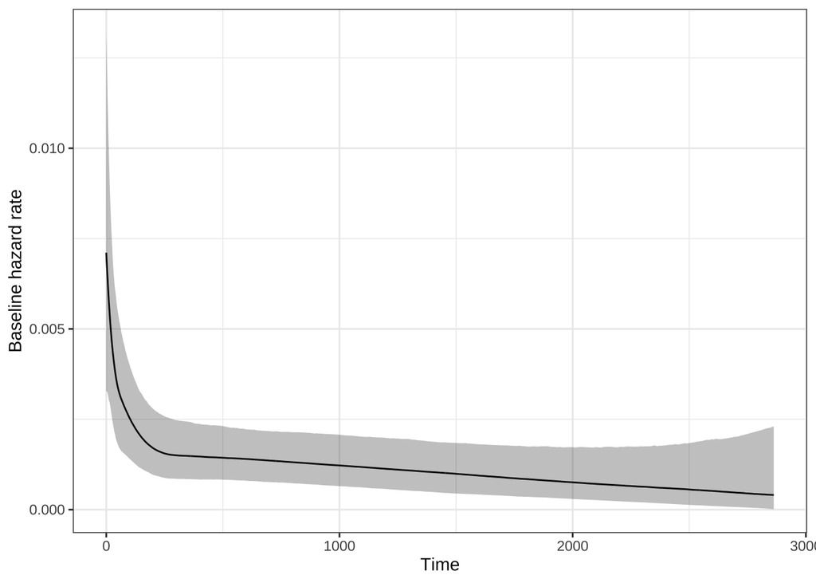

```r
plot(mod_s_age)
```

## Plots of model convergences

## Get results

```r
posterior_mod_s_age <- as.array(mod_s_age)
```

### a. Check trace plots for model

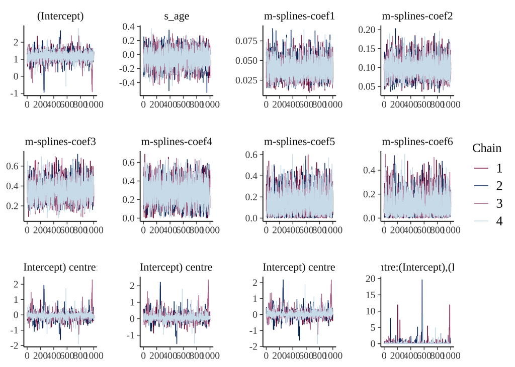

```r
color_scheme_set("mix-blue-pink")
mcmc_trace(posterior_mod_s_age)
```

### b. Trace rank plot

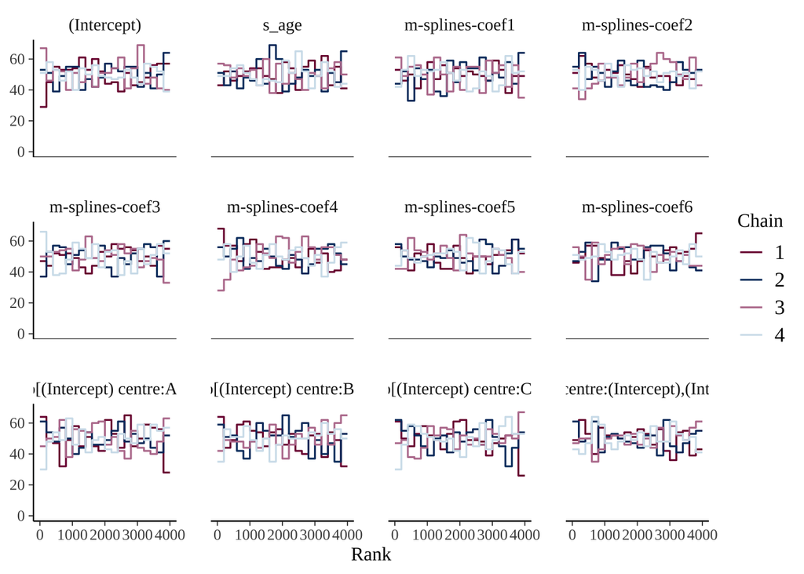

```r
mcmc_rank_overlay(posterior_mod_s_age)
```

### c. get dens overlay plot for chains

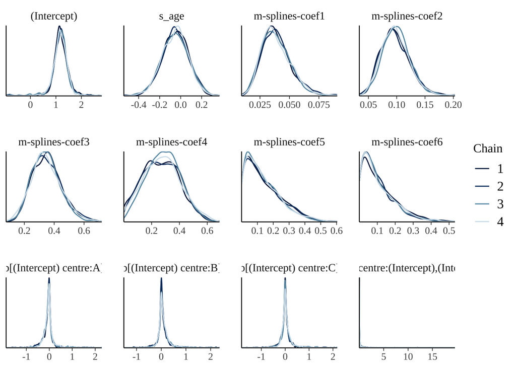

```r
color_scheme_set("blue")
mcmc_dens_overlay(posterior_mod_s_age)
```

## Summaries of coefficients

### HPDI for the different beta parameters

```r
draws <- as.matrix(mod_s_age)
median(draws[,2]) # 2nd column is draws for s_age
```

```
## [1] -0.04932766
```

```r
HPDI(draws[,2], 0.97) # 2nd column is draws for s_age
```

```
##      |0.97      0.97|
## -0.3243069  0.2068668
```

```r
HPDI(draws[,2], 0.89) # 2nd column is draws for s_age
```

```
##      |0.89      0.89|
## -0.2559020  0.1397297
```

### Hypothesis tests on beta parameters

probability that effect is negative

```r
mean(draws[,2] < 0) # 2nd column is draws for surgery
```

```
## [1] 0.65975
```

### a. Get HDI for coefficients

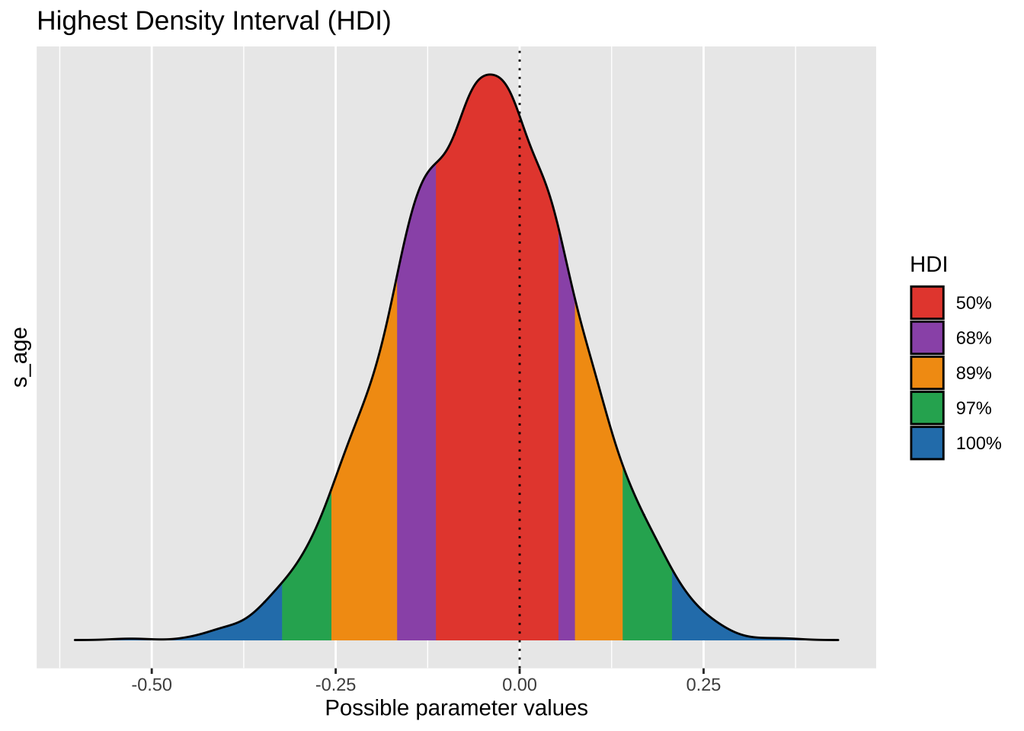

```r
hdi <- bayestestR::hdi(mod_s_age, ci = c(0.50, 0.68, 0.89, 0.97), parameters = "s_age")
plot(hdi)
```

## Get density plots for posterior distributons of beta parameters

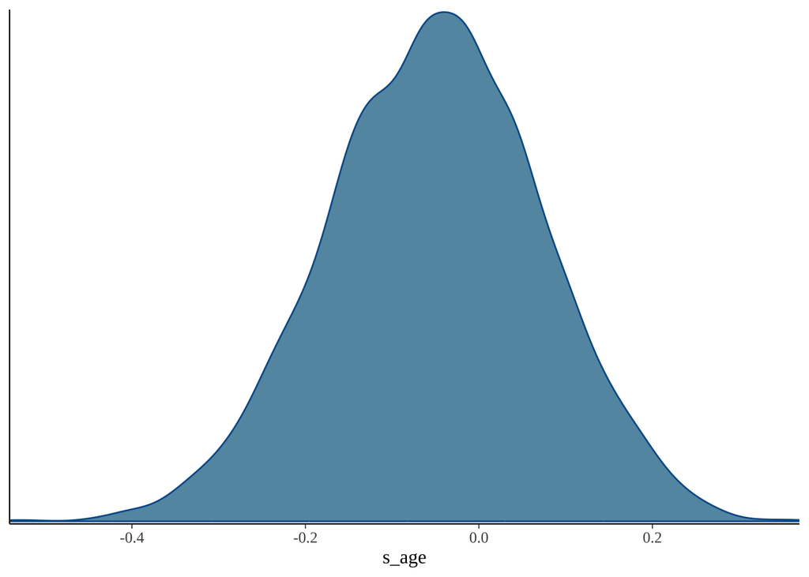

```r
mcmc_dens(posterior_mod_s_age,
  pars = c("s_age"))
```

## Get area plot for posterior distributons of beta parameters

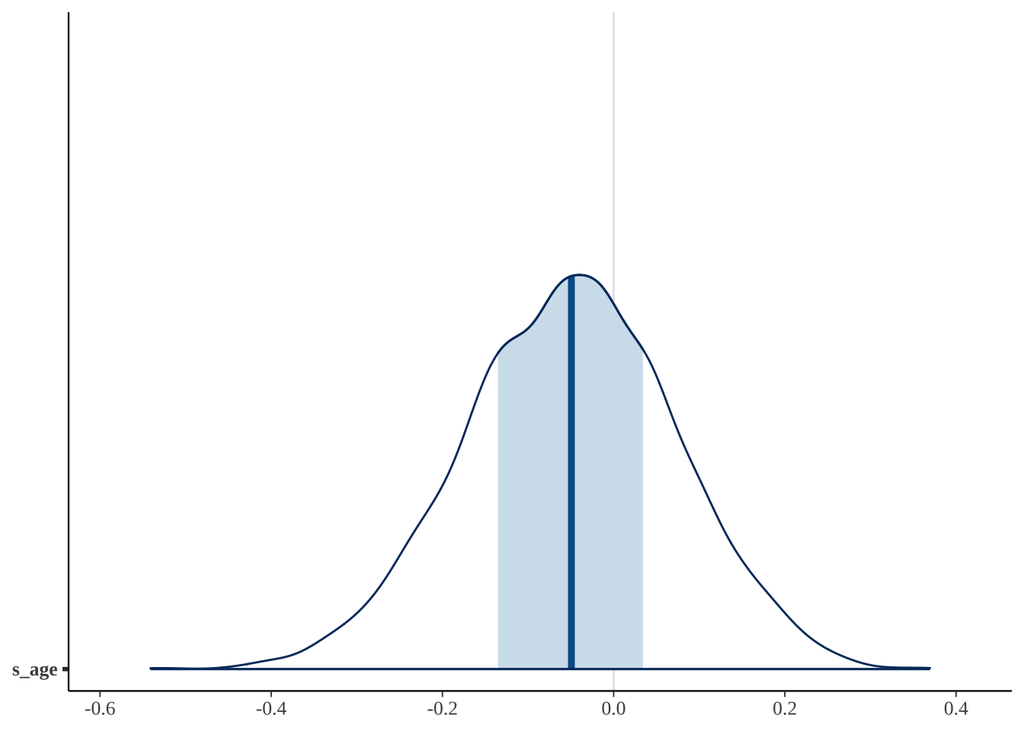

```r
mcmc_areas(posterior_mod_s_age,
  pars = "s_age")
```

## Calculate hazard ratios for s_urgery_age

### a. get posterior draws

```r
s_age_hr <- exp(draws[,2]) # 2nd column is draws for s_age)
```

```r
median(s_age_hr)
```

```
## [1] 0.9518692
```

```r
hdi_s_age_hr <- hdi(s_age_hr, ci = c(0.50, 0.68, 0.89, 0.97))
hdi_s_age_hr
```

```
##          [,1]     [,2]
## [1,] 0.740953 1.201852
```

### c. Plot posterior distribution for hazard ratio of s_age

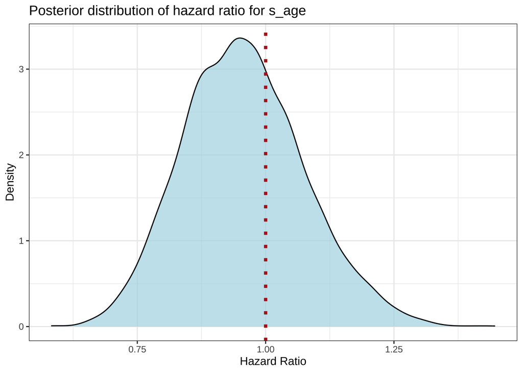

```r
ggplot(data.frame(s_age_hr), aes(x = s_age_hr)) +
  geom_density(fill = "lightblue", alpha = 0.7) +
  labs(title = "Posterior distribution of hazard ratio for s_age",
       x = "Hazard Ratio",
       y = "Density") +
  theme_bw() +
  geom_vline(xintercept = 1, linetype="dotted",
                color = "firebrick", linewidth = 1.5)
```

## Check model performance

### check performance of posterior probability

NB equivalent of pp_check

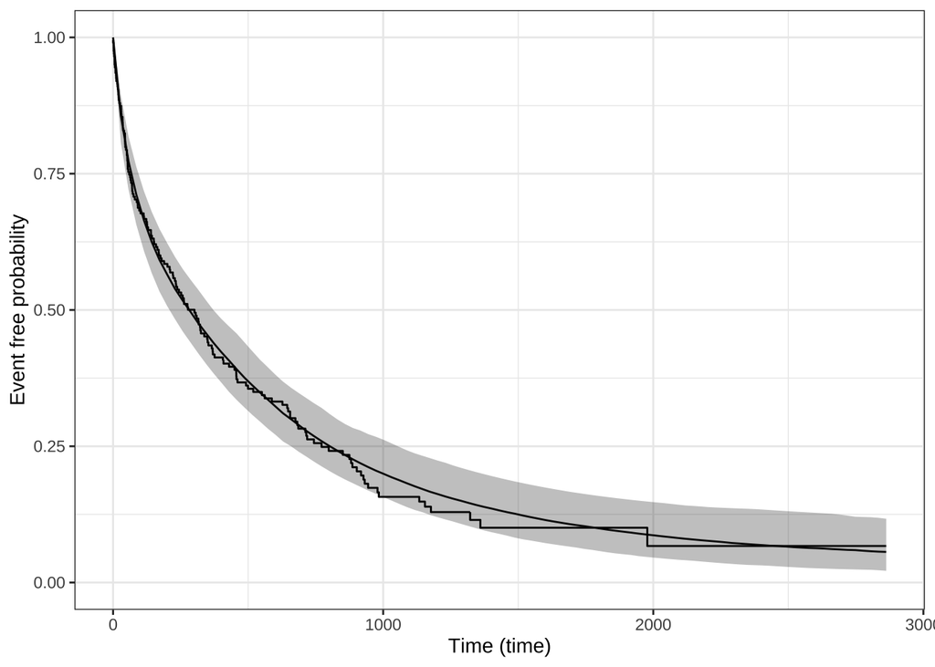

```r
ps_check(mod_sx) |>
  suppressWarnings()
```

### check performance of prior probability

```r
mod_final_prior_only <- update(mod_sx, prior_PD = TRUE)
```

[output not shown]

```
## Also defined by 'rstan'
```

[output not shown]

```
## Also defined by 'rstan'
```

[output not shown]

```
## Also defined by 'rstan'
```

[output not shown]

```
## Also defined by 'rstan'
```

[output not shown]

```
## Also defined by 'rstan'
```

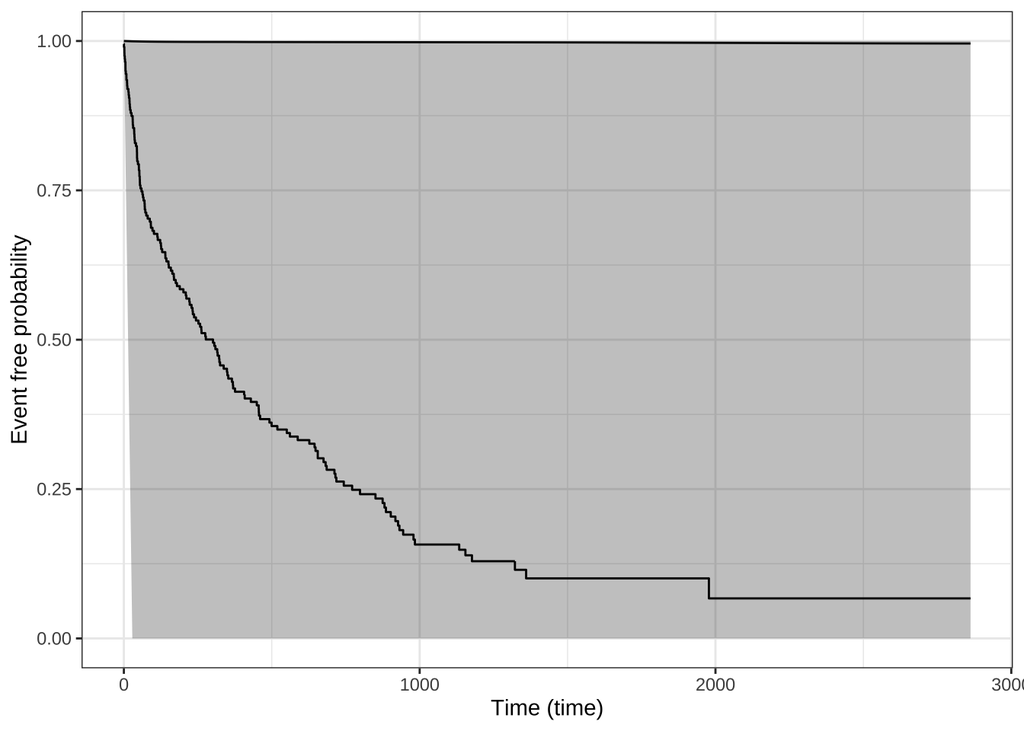

```r
ps_check(mod_final_prior_only) |>
  suppressWarnings()
```

## Make model predictions and plot for s_age

### create new data where age differs

```r
nd <- data.frame(centre = rep("A", 5),
                 s_age = c(-2, -1, 0, 1, 2)
                )
head(nd)
```

```
##   centre s_age
## 1      A    -2
## 2      A    -1
## 3      A     0
## 4      A     1
## 5      A     2
```

### make posterior predictions from new data

```r
ps <- posterior_survfit(mod_s_age,
  newdata = nd,
  times = 0,
  extrapolate = TRUE) |>
  suppressWarnings()
head(ps)
```

```
## stan_surv predictions
##  num. individuals: 5
##  prediction type:  event free probability
##  standardised?:    no
##  conditional?:     no
##
##   id cond_time     time median  ci_lb  ci_ub
## 1  1        NA   0.0000 1.0000 1.0000 1.0000
## 2  1        NA  28.9119 0.8488 0.7124 0.9239
## 3  1        NA  57.8237 0.7616 0.5829 0.8754
## 4  1        NA  86.7356 0.6953 0.4924 0.8394
## 5  1        NA 115.6474 0.6452 0.4240 0.8074
## 6  1        NA 144.5593 0.6050 0.3722 0.7802
```

### plot

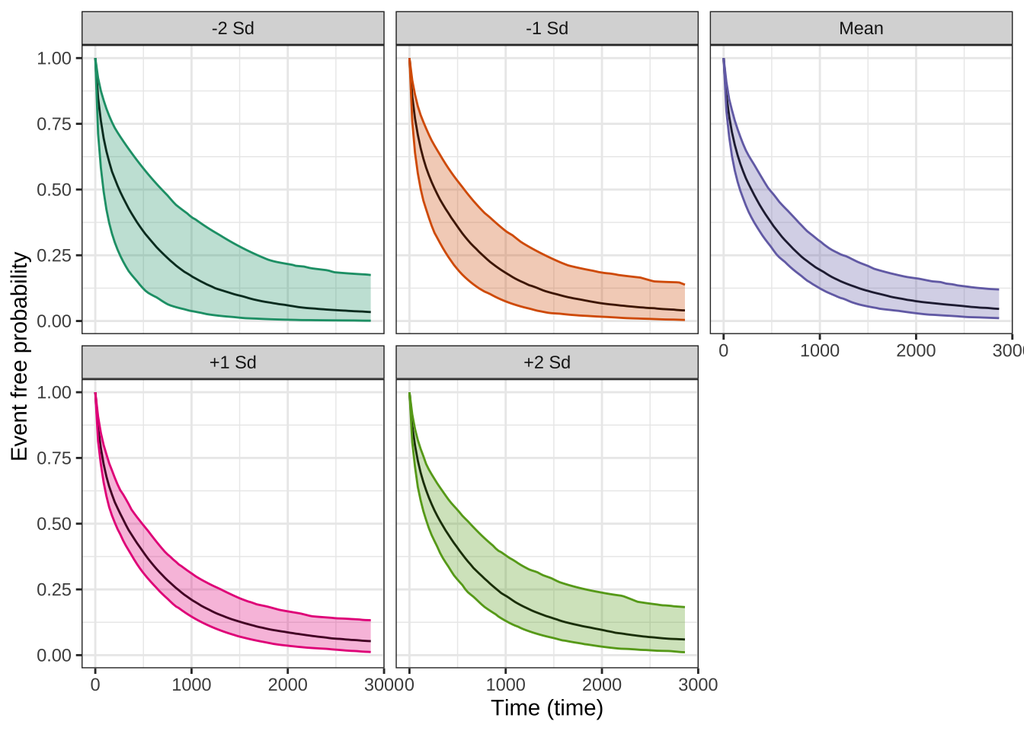

```r
panel_labels <- c('1' = "-2 Sd", '2' = "-1 Sd", '3' = "Mean", '4' = "+1 Sd", '5' = "+2 Sd")
pps <- plot(ps) +
  aes(colour = factor(id), fill = factor(id)) +
  scale_colour_brewer(palette = "Dark2") +
  scale_fill_brewer(palette = "Dark2") +
  theme(legend.position = "none") +
  facet_wrap(~ id, labeller = labeller(id = panel_labels))
print(pps)
```

## Check PH assumption visually

### make predictions of both the hazard and log hazard

```r
ph <- suppressWarnings(posterior_survfit(mod_s_age, newdata = nd, type = "haz"))
pl <- suppressWarnings(posterior_survfit(mod_s_age, newdata = nd, type = "loghaz"))
```

#### create plots

```r
pph <- plot(ph) +
  facet_wrap(~ id, labeller = labeller(id = panel_labels))
ppl <- plot(pl) +
  facet_wrap(~ id, labeller = labeller(id = panel_labels))
```

#### combine plots in grid and plot

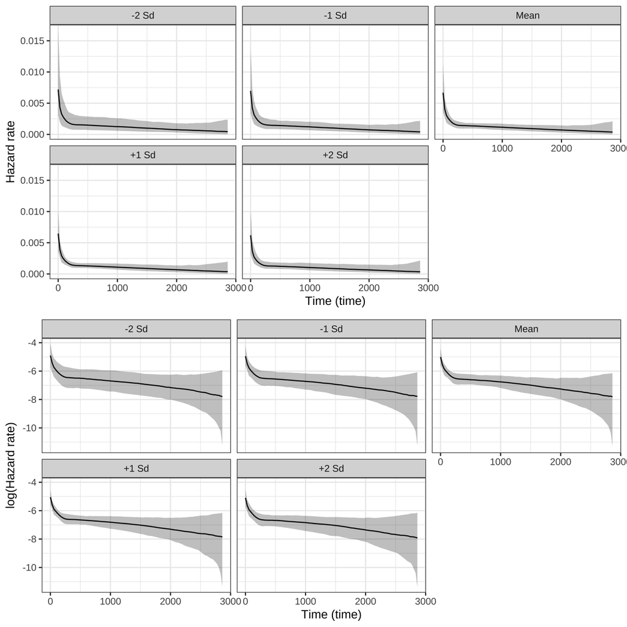

```r
plot_grid(pph, ppl, ncol = 1)
```

## Fit frequentist Cox PH model for effect of s_age

```r
# Fit Cox PH model
freq_cox_s_age <- coxph(Surv(time, status) ~ 1 + s_age + strata(centre),
  data = sim_data)

summary(freq_cox_s_age)
```

```
## Call:
## coxph(formula = Surv(time, status) ~ 1 + s_age + strata(centre),
##     data = sim_data)
##
##   n= 200, number of events= 159
##
##           coef exp(coef) se(coef)      z Pr(>|z|)
## s_age -0.08425   0.91920  0.12919 -0.652    0.514
##
##       exp(coef) exp(-coef) lower .95 upper .95
## s_age    0.9192      1.088    0.7136     1.184
##
## Concordance= 0.542  (se = 0.027 )
## Likelihood ratio test= 0.43  on 1 df,   p=0.5
## Wald test            = 0.43  on 1 df,   p=0.5
## Score (logrank) test = 0.43  on 1 df,   p=0.5
```

## III. Bayesian Cox’s regression for EFFECT OF chf with random intercept for centre

## Non-informative prior for chf

**Set a non-informative weekly regularising prior…**

student_t(df = 3, location = 0, scale = 2)

```r
prior_chf <- student_t(df = 3,
                           location = 0,
                           scale = 2,
                           autoscale = FALSE)
```

NB use status … rstanarm requires the dead animals to be classified as 1, whilst censored are 0.

```r
mod_chf <- stan_surv(formula = Surv(time, status) ~ 1 + chf +  (1| centre),
  data = sim_data,
  basehaz = "ms",
  prior = prior_chf,
  prior_intercept = normal(location = 0, scale = 20, autoscale = FALSE),
  prior_covariance =  decov(regularization = 2, concentration = 1, shape = 1, scale = 1),
  iter    = 2000,
  chains = 4,
  cores = 4,
  adapt_delta = 0.999,  # Often helpful for complex models
  seed = 666)
```

[output not shown]

```
## Also defined by 'rstan'
```

[output not shown]

```
## Also defined by 'rstan'
```

[output not shown]

```
## Also defined by 'rstan'
```

[output not shown]

```
## Also defined by 'rstan'
```

[output not shown]

```
## Also defined by 'rstan'
```

## Summarise priors from model

```r
prior_summary(mod_chf)
```

```
## Priors for model 'mod_chf'
## ------
## Intercept
##  ~ normal(location = 0, scale = 20)
##
## Coefficients
##  ~ student_t(df = 3, location = 0, scale = 2)
##
## Auxiliary (M-spline-coefficients)
##  ~ dirichlet(concentration = [1,1,1,...])
##
## Covariance
##  ~ decov(reg. = 2, conc. = 1, shape = 1, scale = 1)
## ------
## See help('prior_summary.stanreg') for more details
```

## Model summary

```r
summary(mod_chf)
```

```
##
## Model Info:
##
##  function:        stan_surv
##  baseline hazard: M-splines on hazard scale
##  formula:         Surv(time, status) ~ 1 + chf + (1 | centre)
##  algorithm:       sampling
##  sample:          4000 (posterior sample size)
##  priors:          see help('prior_summary')
##  observations:    200
##  events:          159 (79.5%)
##  right censored:  41 (20.5%)
##  delayed entry:   no
##
## Estimates:
##                                         mean   sd   10%   50%   90%
## (Intercept)                            1.1    0.3  0.8   1.1   1.4
## chf                                    1.9    0.2  1.6   1.9   2.2
## m-splines-coef1                        0.0    0.0  0.0   0.0   0.0
## m-splines-coef2                        0.1    0.0  0.0   0.1   0.1
## m-splines-coef3                        0.3    0.1  0.2   0.3   0.5
## m-splines-coef4                        0.3    0.1  0.1   0.3   0.5
## m-splines-coef5                        0.1    0.1  0.0   0.1   0.3
## m-splines-coef6                        0.1    0.1  0.0   0.1   0.3
## b[(Intercept) centre:A]               -0.1    0.2 -0.3   0.0   0.1
## b[(Intercept) centre:B]                0.1    0.2 -0.1   0.0   0.3
## b[(Intercept) centre:C]                0.0    0.2 -0.3   0.0   0.1
## Sigma[centre:(Intercept),(Intercept)]  0.1    0.5  0.0   0.0   0.3
##
## MCMC diagnostics
##                                       mcse Rhat n_eff
## (Intercept)                           0.0  1.0  1519
## chf                                   0.0  1.0  3113
## m-splines-coef1                       0.0  1.0  3600
## m-splines-coef2                       0.0  1.0  4037
## m-splines-coef3                       0.0  1.0  3061
## m-splines-coef4                       0.0  1.0  2268
## m-splines-coef5                       0.0  1.0  2640
## m-splines-coef6                       0.0  1.0  4200
## b[(Intercept) centre:A]               0.0  1.0  1382
## b[(Intercept) centre:B]               0.0  1.0  1247
## b[(Intercept) centre:C]               0.0  1.0  1333
## Sigma[centre:(Intercept),(Intercept)] 0.0  1.0  1729
## log-posterior                         0.1  1.0  1178
##
## For each parameter, mcse is Monte Carlo standard error, n_eff is a crude measure of effective sample size, and Rhat is the potential scale reduction factor on split chains (at convergence Rhat=1).
```

## Model short summary

```r
print(mod_chf, digits = 3)
```

```
## stan_surv
##  baseline hazard: M-splines on hazard scale
##  formula:         Surv(time, status) ~ 1 + chf + (1 | centre)
##  observations:    200
##  events:          159 (79.5%)
##  right censored:  41 (20.5%)
##  delayed entry:   no
## ------
##                 Median MAD_SD exp(Median)
## (Intercept)     1.100  0.237     NA
## chf             1.917  0.222  6.804
## m-splines-coef1 0.019  0.007     NA
## m-splines-coef2 0.061  0.018     NA
## m-splines-coef3 0.334  0.104     NA
## m-splines-coef4 0.313  0.153     NA
## m-splines-coef5 0.116  0.111     NA
## m-splines-coef6 0.089  0.086     NA
##
## Error terms:
##  Groups Name        Std.Dev.
##  centre (Intercept) 0.3734
## Num. levels: centre 3
##
## ------
## * For help interpreting the printed output see ?print.stanreg
## * For info on the priors used see ?prior_summary.stanreg
```

## Plot Baseline hazard of model

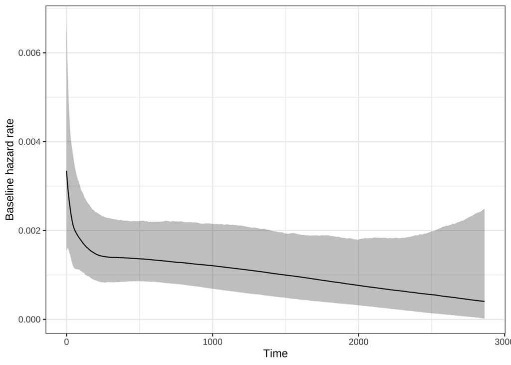

```r
plot(mod_chf)
```

## Plots of model convergences

## Get results

```r
posterior_mod_chf <- as.array(mod_chf)
```

### a. Check trace plots for model

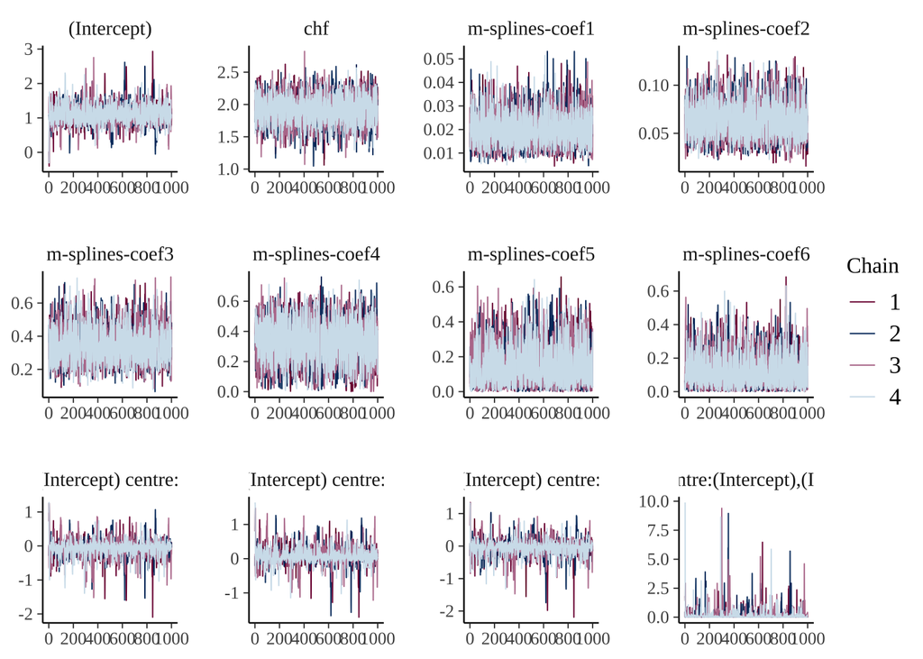

```r
color_scheme_set("mix-blue-pink")
mcmc_trace(posterior_mod_chf)
```

### b. Trace rank plot

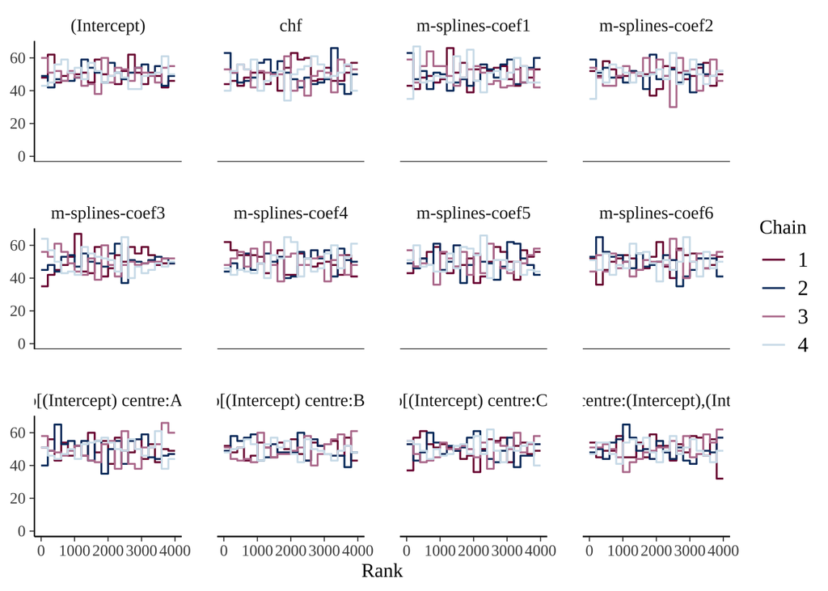

```r
mcmc_rank_overlay(posterior_mod_chf)
```

### c. get dens overlay plot for chains

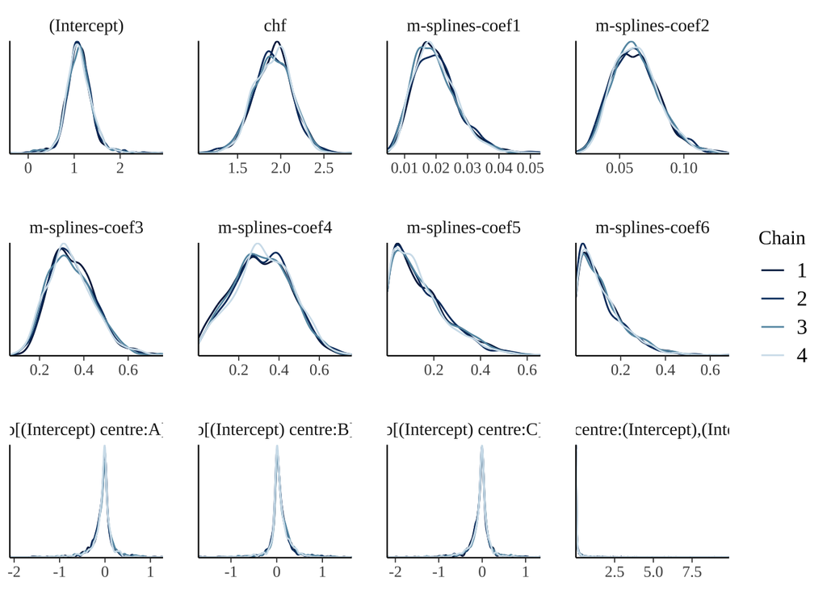

```r
color_scheme_set("blue")
mcmc_dens_overlay(posterior_mod_chf)
```

## Summaries of coefficients

### HPDI for the different beta parameters

```r
draws <- as.matrix(mod_chf)
median(draws[,2]) # 2nd column is draws for chf
```

```
## [1] 1.917468
```

```r
HPDI(draws[,2], 0.97) # 2nd column is draws for chf
```

```
##    |0.97    0.97|
## 1.423429 2.387347
```

```r
HPDI(draws[,2], 0.89) # 2nd column is draws for chf
```

```
##    |0.89    0.89|
## 1.571871 2.274619
```

### Hypothesis tests on beta parameters

probability that effect is negative

```r
mean(draws[,2] < 0) # 2nd column is draws for surgery
```

```
## [1] 0
```

### a. Get HDI for coefficients

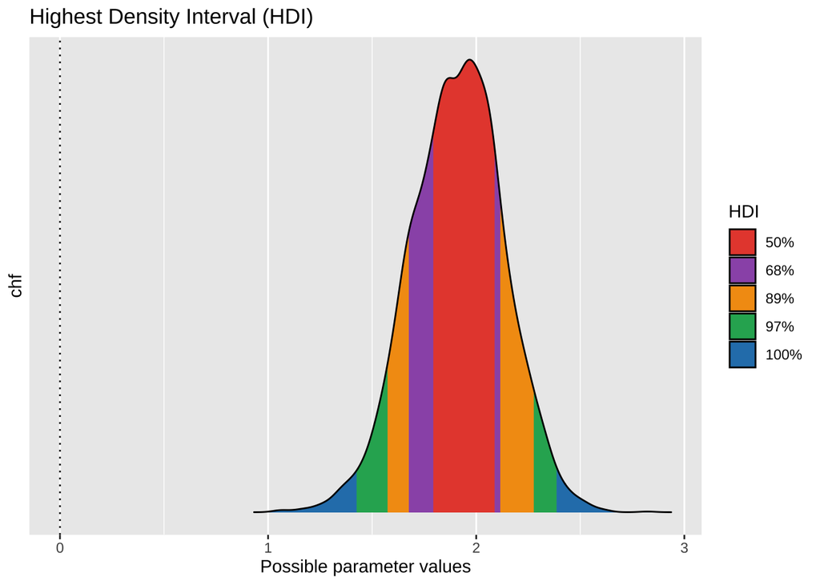

```r
hdi <- bayestestR::hdi(mod_chf, ci = c(0.50, 0.68, 0.89, 0.97), parameters = "chf")
plot(hdi)
```

## Get density plots for posterior distributons of beta parameters

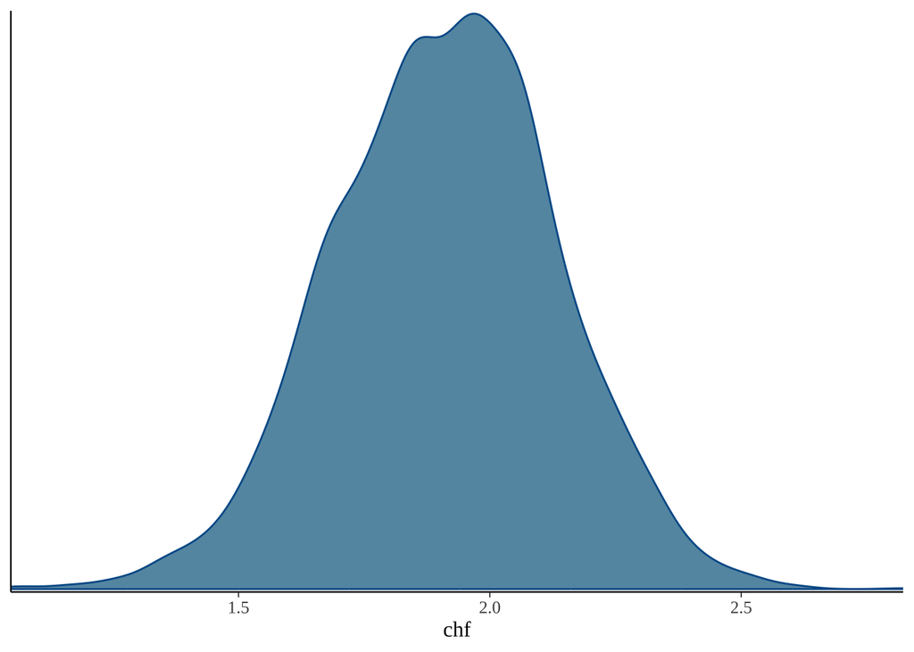

```r
mcmc_dens(posterior_mod_chf,
  pars = c("chf"))
```